# Tutorial — Construção de Gráficos no R

Parte 1 — Do R Base à Gramática de Gráficos com ggplot2

Métodos Computacionais 1

# 1 Objetivos

Ao final deste tutorial, você deverá ser capaz de:

- Compreender a filosofia da “Gramática de Gráficos” do pacote `ggplot2`;
- Diferenciar mapeamento estético dentro de `aes()` de customizações fixas;
- Modificar os principais elementos visuais (títulos, eixos, cores e temas);
- Dominar o funcionamento profundo e os componentes da camada `theme()`;
- Customizar legendas (posição, títulos, textos e caixas) e eixos (títulos, textos, rotação e linhas);
- Construir histogramas, boxplots, gráficos de dispersão, linhas e barras de forma elegante;
- Compreender e aplicar gráficos de séries temporais com múltiplas linhas de forma correta;
- Utilizar facetas (`facet_wrap` e `facet_grid`) para analisar subgrupos;
- Dominar o ajuste fino de gráficos (rotacionar eixos, mover legendas, aplicar paletas e formatar números com o pacote `scales`);
- Combinar múltiplos gráficos independentes em um único layout com `patchwork` e `ggExtra`;
- Evitar e diagnosticar os principais erros comuns de iniciantes (Troubleshooting);
- Salvar gráficos programaticamente com `ggsave()`.

# 2 1. Introdução: O Ecossistema ggplot2

O R possui um sistema nativo para construção de gráficos (pacote `graphics`), que funciona como uma “tela de pintura” em etapas, adicionando elementos diretamente por cima do anterior.

No entanto, o padrão moderno para análise de dados utiliza o pacote **ggplot2** (membro do `tidyverse`). O `ggplot2` baseia-se na **Gramática de Gráficos**, onde uma visualização é construída por meio de **camadas (layers)** sobrepostas usando o operador `+`.

Para começar, precisamos carregar os pacotes necessários:

```r
# Caso não tenha instalado, execute no console antes de compilar:
# install.packages(c("ggplot2", "patchwork", "ggExtra", "scales"))
library(ggplot2)
library(scales)
```

## 2.1 A Tabela de Componentes do ggplot2

| Componente / Função | Utilização |
| --- | --- |
| **`ggplot(data, aes())`** | Inicializa o gráfico, define o banco de dados e os mapeamentos estéticos básicos |
| **`geom_point()`** | Adiciona uma camada de pontos (Gráfico de dispersão) |
| **`geom_line()`** | Adiciona uma camada de linhas (Séries temporais/tendências) |
| **`geom_segment()`** | Desenha segmentos de reta entre coordenadas específicas |
| **`geom_abline()`** | Adiciona retas definidas por inclinação e intercepto, ou linhas horizontais/verticais (`geom_hline`, `geom_vline`) |
| **`geom_smooth()`** | Adiciona linhas de tendência (como regressão linear) com intervalos de confiança |
| **`labs()`** | Modifica títulos, subtítulos, legendas e rótulos dos eixos |
| **`theme()`** | Customiza componentes globais do gráfico (fontes, fundos, margens, eixos, legendas) |

# 3 2. A função `ggplot()` e o Mapeamento Estético

O `ggplot2` exige estritamente que os dados estejam organizados em formato de tabela (`data.frame` ou `tibble`).

Vamos considerar o exemplo: Idade Gestacional, em semanas ($x$) e Peso ao Nascer ($y$), em gramas, para 12 recém-nascidos.

```r
df_gestacao <- data.frame(
  x = c(32, 33, 34, 34, 35, 36, 37, 37, 38, 39, 40, 41),
  y = c(1900, 1750, 2200, 1950, 2600, 2300, 2850, 2500, 3200, 2900, 3500, 3100)
)
```

Para gerar um **gráfico de dispersão**, nós inicializamos a estrutura com `ggplot()`, mapeamos as variáveis dentro de `aes()` (aesthetics) e adicionamos a geometria de pontos usando o `+`:

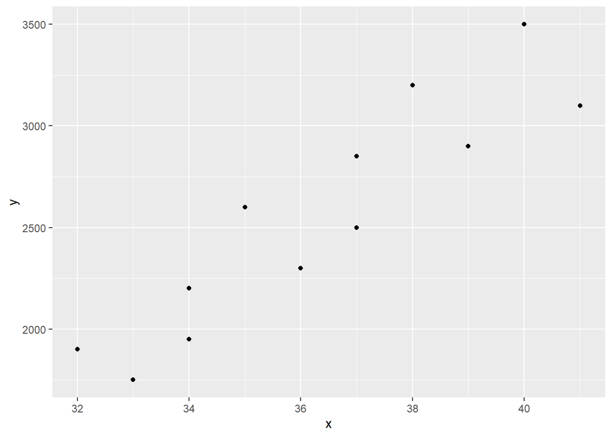

```r
ggplot(data = df_gestacao, aes(x = x, y = y)) +
  geom_point()
```

# 4 3. Entendendo o Escopo: Estética Global vs. Local (Dentro ou Fora de aes?)

Um dos maiores erros ao iniciar no `ggplot2` é confundir onde aplicar argumentos visuais como cor (`color`), tamanho (`size`) ou formato do ponto (`shape`).

- **Mapeamento (Dentro de `aes()`):** Use quando a propriedade visual deve variar **de acordo com uma variável** da sua tabela. O `ggplot2` criará uma legenda automaticamente.
- **Configuração Fixa (Fora de `aes()`):** Use diretamente dentro da geometria (`geom_*`) quando quiser aplicar uma alteração constante para **todos** os pontos, independente dos dados.

### 4.0.1 Exemplo de Configuração Fixa (Fora de `aes`)

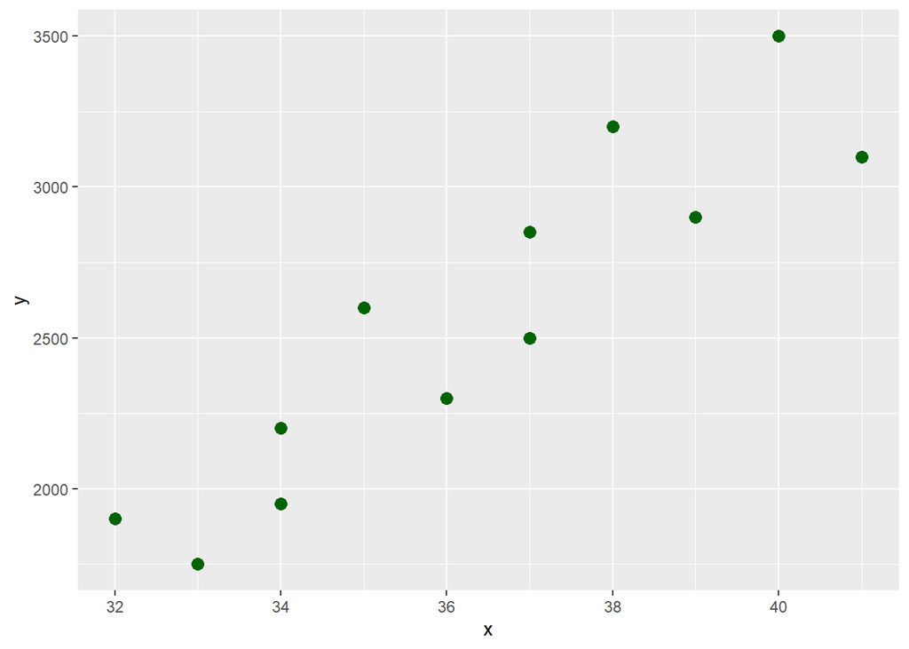

```r
ggplot(df_gestacao, aes(x = x, y = y)) +
  geom_point(color = "darkgreen", shape = 16, size = 3) # Todos os pontos mudam juntos
```

# 5 3.1. Gráficos de Linhas e Evolução Temporal (`geom_line`)

Para dados que representam evolução (como séries temporais ou acompanhamentos), utilizamos a geometria `geom_line()`.

**A grande pegadinha:** Quando seu conjunto de dados possui mais de um grupo ou categoria (por exemplo, dados coletados para diferentes indivíduos ou tratamentos ao longo do tempo), você deve mapear obrigatoriamente a propriedade estética **`group`** dentro de `aes()`. Se você esquecer o `group`, o `ggplot2` tentará conectar todos os dados em uma única linha em zigue-zague confuso.

Combinar `geom_line()` com `geom_point()` é uma excelente prática visual, facilitando a identificação dos momentos exatos das coletas.

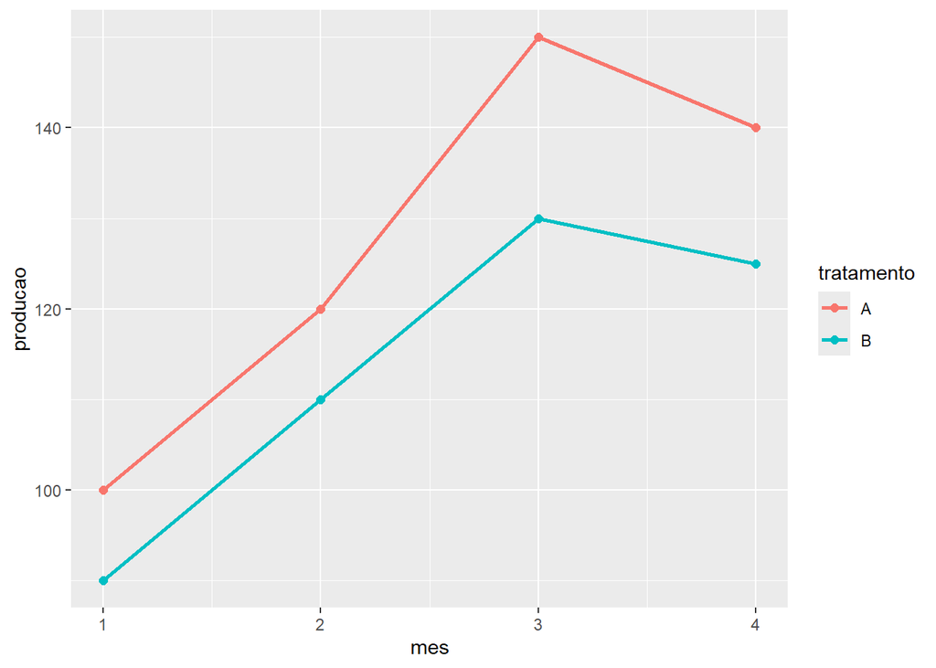

```r
df_tempo_exemplo <- data.frame(
  mes = rep(1:4, times = 2),
  producao = c(100, 120, 150, 140,  # Tratamento A
               90, 110, 130, 125),   # Tratamento B
  tratamento = rep(c("A", "B"), each = 4)
)

# Correto com mapeamento de grupo
ggplot(df_tempo_exemplo, aes(x = mes, y = producao, color = tratamento, group = tratamento)) +
  geom_line(size = 1) +
  geom_point(size = 2)
```

# 6 4. Modificando Elementos Principais e Títulos

Em vez de múltiplos argumentos congestionando a mesma função, usamos as funções auxiliares `labs()`, `xlim()` e `ylim()` conectadas por `+`.

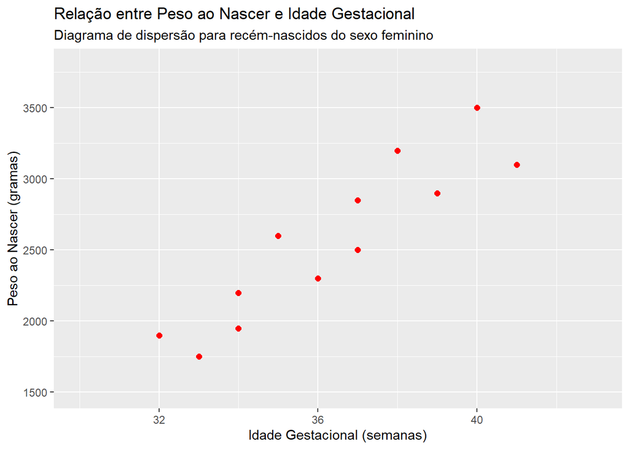

```r
ggplot(df_gestacao, aes(x = x, y = y)) +
  geom_point(color = "red", size = 2) +
  labs(
    title = "Relação entre Peso ao Nascer e Idade Gestacional",
    subtitle = "Diagrama de dispersão para recém-nascidos do sexo feminino",
    x = "Idade Gestacional (semanas)",
    y = "Peso ao Nascer (gramas)"
  ) +
  xlim(30, 43) +
  ylim(1500, 3800)
```

# 7 5. Aprofundamento: Domínio da Camada `theme()`

A função `theme()` controla a exibição de elementos não estatísticos do gráfico. Enquanto `aes()` mapeia dados a propriedades visuais, `theme()` dita a aparência da estrutura ao redor desses dados.

## 7.1 As Quatro Funções Auxiliares Fundamentais

Para modificar elementos específicos dentro de `theme()`, usamos quatro funções especializadas baseadas na natureza do elemento:

1. **`element_text()`**: Modifica propriedades de texto como fonte (`family`), tamanho (`size`), estilo (`face` como `"bold"`, `"italic"`), cor (`color`) e alinhamento (`hjust`, `vjust`, `angle`).
2. **`element_line()`**: Customiza linhas estruturais como eixos, linhas de grade e bordas. Aceita cor (`color`), espessura (`size` ou `linewidth`) e tipo de linha (`linetype`).
3. **`element_rect()`**: Altera superfícies retangulares/caixas, como o fundo do gráfico, fundo dos painéis ou contorno das legendas. Aceita preenchimento (`fill`) e borda (`color`).
4. **`element_blank()`**: Omite ou remove completamente o elemento visual do layout (útil para desligar grades ou fundos indesejados).

## 7.2 Anatomia do Controle de Eixos

Os eixos contam com uma hierarquia precisa de argumentos para manipulação individual ou conjunta:

- **Títulos dos Eixos:** Modificados com `axis.title`, `axis.title.x` e `axis.title.y`.
- **Textos/Rótulos das Escalas:** Controlados com `axis.text`, `axis.text.x` e `axis.text.y`. Muito utilizado para aplicar rotação (`angle`) e alinhamento vertical/horizontal (`vjust`, `hjust`) para evitar sobreposição de textos longos.
- **Linhas dos Eixos:** Customizadas via `axis.line`, `axis.line.x` e `axis.line.y`.

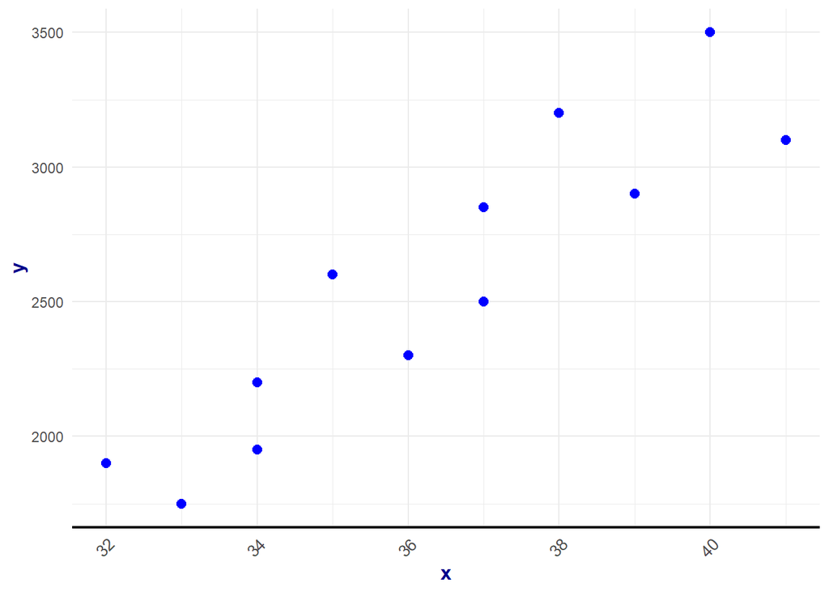

```r
# Exemplo prático de ajuste fino nos eixos
ggplot(df_gestacao, aes(x = x, y = y)) +
  geom_point(color = "blue", size = 2.5) +
  theme_minimal() +
  theme(
    # Customizando os títulos dos eixos (negrito e tamanho maior)
    axis.title = element_text(face = "bold", size = 12, color = "darkblue"),
    # Rotacionando os rótulos do eixo X em 45 graus para evitar sobreposições
    axis.text.x = element_text(angle = 45, hjust = 1, size = 10),
    # Engrossando e alterando a cor da linha base do eixo X
    axis.line.x = element_line(color = "black", linewidth = 0.8)
  )
```

## 7.3 Anatomia do Controle de Legendas

A customização visual e estrutural da legenda é crucial para relatórios acadêmicos e corporativos:

- **Posicionamento (`legend.position`):** Aceita strings pré-definidas (`"top"`, `"bottom"`, `"left"`, `"right"`) ou desativação completa (`"none"`). Também aceita posicionamento interno exato passando coordenadas numéricas proporcionais como `c(x, y)` entre `0` e `1`.
- **Direcionamento e Layout (`legend.direction` e `legend.box`):** Determina se os elementos da legenda fluem na `"horizontal"` ou `"vertical"`.
- **Estilização de Textos:** Separado entre `legend.title` (para o cabeçalho) e `legend.text` (para as categorias/itens mapeados).
- **Fundo e Caixa (`legend.background` e `legend.key`):** Modifica a área geral do bloco da legenda e o fundo individual sob cada símbolo/ícone.

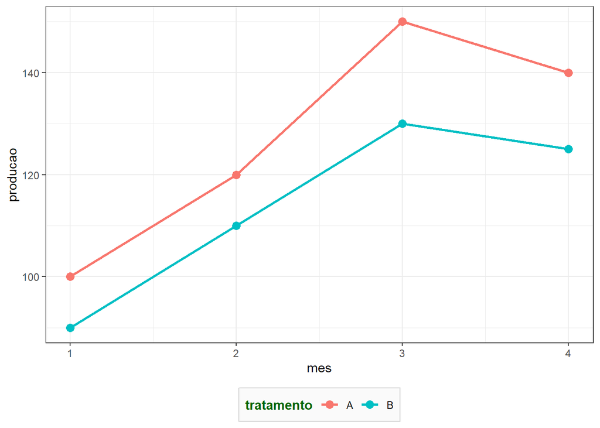

```r
# Exemplo prático de ajuste fino na legenda interna do gráfico
ggplot(df_tempo_exemplo, aes(x = mes, y = producao, color = tratamento, group = tratamento)) +
  geom_line(linewidth = 1) +
  geom_point(size = 3) +
  theme_bw() +
  theme(
    # Move a legenda para a base horizontal
    legend.position = "bottom",
    legend.direction = "horizontal",
    # Aplica negrito apenas ao título da legenda
    legend.title = element_text(face = "bold", color = "darkgreen"),
    # Limpa o fundo dos quadradinhos da legenda deixando-os transparentes
    legend.key = element_blank(),
    # Cria uma borda fina cinza ao redor da caixa externa da legenda
    legend.background = element_rect(fill = "gray98", color = "lightgray")
  )
```